# Individual Project

# Load Required Packages

```r
# install.packages("openxlsx")
library(openxlsx)
# install.packages("ggplot2")
library(ggplot2)
# install.packages("ggpubr")
# install.packages("ggthemes")
library(ggpubr)
library(ggthemes)
# install.packages("gmodels")
library(gmodels)
library(export)
library(tidyverse)
Brown_adipose_2022 = read.xlsx("Brown adipose 2022.xlsx", rowNames = FALSE)
head(Brown_adipose_2022)
```

```
##                                                                                                                                             Feature
## 1                                                                                                                                 (+/-)-Homoproline
## 2                                                                                                                             (2E)-2-Pentenoic acid
## 3                                                                                                                        (2E)-hexadecenoylcarnitine
## 4                                                                                                               (2S)-2-Amino-8-hydroxyoctanoic acid
## 5                                                                                 (2S)-2-Methyl-4-(3H-purin-6-ylamino)butyl alpha-D-glucopyranoside
## 6 (2S)-3-(1H-Imidazol-4-yl)-2-({[(3S,4S,5R)-2,3,4-trihydroxy-5-(hydroxymethyl)tetrahydro-2-furanyl]methyl}amino)propanoic acid (non-preferred name)
##     4_IBA_23   4_IBA_25   4_IBA_32   4_IBA_35   4_IBA_37   4_IBA_38   4_IBA_39
## 1 12991020.5 18736018.8 12365800.0  9598118.6 12902812.5 17218957.9 16339656.0
## 2  7551573.4  2743499.8  4405031.2  3946608.7 11211853.7 12318863.3  4603062.3
## 3 14637396.6 93751516.3 20766576.6 15634104.9  6387307.2 28243580.2 15551994.0
## 4   209803.4   267446.3   126055.4   726352.6   561805.2  1117378.6   760431.7
## 5 14125882.1  9852609.4  9895534.7  2829625.3  8394486.2  7169654.1  6966842.8
## 6   427398.8   177241.4   498147.3   653298.3   633161.6   464572.1   737647.0
##     4_IBA_40   5_MAR_41   5_MAR_42   5_MAR_43   5_MAR_44   5_MAR_45   5_MAR_46
```

[output cut: 41 more lines]

```r
dat2 = t(Brown_adipose_2022[, 2:49])
dat2 = as.data.frame(dat2)
Type = c(rep("4_IBA", 8), rep("5_MAR", 8), rep("2_OCT", 9), rep("1_SEP", 9), rep("3_TOR", 14))
dat2$Type = Type
ord = prcomp(dat2[, 1:356])
summary(ord)
```

```
## Importance of components:
##                              PC1       PC2       PC3       PC4       PC5
## Standard deviation     5.223e+09 3.049e+09 2.270e+09 1.892e+09 1.759e+09
## Proportion of Variance 4.546e-01 1.549e-01 8.589e-02 5.963e-02 5.158e-02
## Cumulative Proportion  4.546e-01 6.096e-01 6.955e-01 7.551e-01 8.067e-01
##                              PC6       PC7       PC8       PC9      PC10
## Standard deviation     1.508e+09 1.422e+09 1.315e+09 1.014e+09 9.628e+08
## Proportion of Variance 3.789e-02 3.369e-02 2.883e-02 1.712e-02 1.545e-02
## Cumulative Proportion  8.446e-01 8.783e-01 9.071e-01 9.242e-01 9.397e-01
##                             PC11      PC12      PC13      PC14      PC15
## Standard deviation     8.758e+08 7.966e+08 7.247e+08 6.742e+08 5.108e+08
## Proportion of Variance 1.278e-02 1.057e-02 8.750e-03 7.570e-03 4.350e-03
## Cumulative Proportion  9.525e-01 9.630e-01 9.718e-01 9.794e-01 9.837e-01
##                             PC16      PC17      PC18      PC19      PC20
## Standard deviation     4.507e+08 4.350e+08 3.739e+08 2.928e+08 2.519e+08
## Proportion of Variance 3.380e-03 3.150e-03 2.330e-03 1.430e-03 1.060e-03
## Cumulative Proportion  9.871e-01 9.902e-01 9.926e-01 9.940e-01 9.950e-01
##                             PC21      PC22      PC23      PC24      PC25
## Standard deviation     2.245e+08 2.092e+08 1.888e+08 1.743e+08 1.547e+08
## Proportion of Variance 8.400e-04 7.300e-04 5.900e-04 5.100e-04 4.000e-04
## Cumulative Proportion  9.959e-01 9.966e-01 9.972e-01 9.977e-01 9.981e-01
##                             PC26      PC27      PC28      PC29      PC30
## Standard deviation     1.361e+08 1.212e+08 1.145e+08 1.082e+08 9.984e+07
## Proportion of Variance 3.100e-04 2.400e-04 2.200e-04 2.000e-04 1.700e-04
## Cumulative Proportion  9.984e-01 9.987e-01 9.989e-01 9.991e-01 9.992e-01
##                             PC31      PC32      PC33      PC34      PC35
## Standard deviation     9.572e+07 8.002e+07 7.423e+07 6.456e+07 6.339e+07
## Proportion of Variance 1.500e-04 1.100e-04 9.000e-05 7.000e-05 7.000e-05
## Cumulative Proportion  9.994e-01 9.995e-01 9.996e-01 9.997e-01 9.997e-01
##                             PC36      PC37      PC38      PC39      PC40
## Standard deviation     5.487e+07 5.165e+07 4.731e+07 4.091e+07 3.775e+07
## Proportion of Variance 5.000e-05 4.000e-05 4.000e-05 3.000e-05 2.000e-05
## Cumulative Proportion  9.998e-01 9.998e-01 9.999e-01 9.999e-01 9.999e-01
##                             PC41      PC42      PC43      PC44      PC45
## Standard deviation     3.324e+07 3.238e+07 2.614e+07 2.416e+07 2.134e+07
## Proportion of Variance 2.000e-05 2.000e-05 1.000e-05 1.000e-05 1.000e-05
## Cumulative Proportion  9.999e-01 1.000e+00 1.000e+00 1.000e+00 1.000e+00
##                             PC46     PC47      PC48
## Standard deviation     1.977e+07 17041157 7.383e-07
## Proportion of Variance 1.000e-05        0 0.000e+00
## Cumulative Proportion  1.000e+00        1 1.000e+00
```

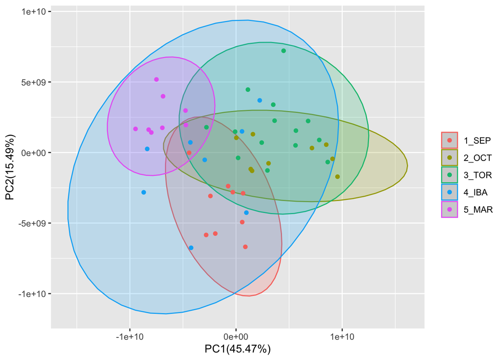

```r
dt <- ord$x

df <- data.frame(dt, Type = dat2$Type)

xlab <- paste0("PC1(", round(summary(ord)$importance[2, 1] * 100, 2), "%)")
ylab <- paste0("PC2(", round(summary(ord)$importance[2, 2] * 100, 2), "%)")

library(ggplot2)
library(dplyr)

ggplot(df, aes(df$PC1, df$PC2, color = Type)) +
  stat_ellipse(aes(fill = Type), type = "norm", geom = "polygon", alpha = 0.2) +
  guides(fill = "none") +
  geom_point() +
  labs(x = xlab, y = ylab, color = "")
```

#whole data heatmap plot Sets the color scale for the fill color. The heatmap will have a gradient from white (low values) to red (high values).Extracts columns 2 to 49 (assumed to be the compound data) from the original dataframe.

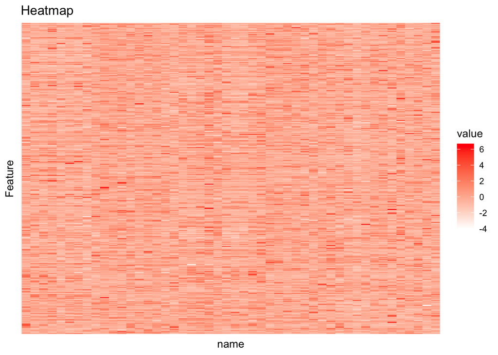

```r
a=Brown_adipose_2022 %>%
  mutate(feature=seq(1:nrow(Brown_adipose_2022))) %>%
  select(-Feature) %>%
  pivot_longer(-feature)


dat=Brown_adipose_2022[,2:49]
dat1=apply(dat,1,function(x) scale(x))
#t(dat1) #don't print
dat2=data.frame(Feature=Brown_adipose_2022[,1])
dat3=cbind(dat2, t(dat1))

library(ggplot2)
ggplot(data = pivot_longer(dat3, -Feature), aes(x = name, y = Feature, fill = value)) +
  geom_tile() +
  scale_fill_gradient(low = "white", high = "red") +
  theme_minimal() +
  labs(title = "Heatmap") +
  theme(axis.text.x = element_text(angle = 48, hjust = 1)) +
  theme(axis.text.y=element_blank(), axis.text.x=element_blank())
```

variable data heatmap The data should be separate according to the variable. According to the results shown in the console, the variables are in the order: #1 columns 2-9 are IBA. #2 columns 10-17 are MAR. #3 columns 18-26 are OCT. #4 columns 27-35 are SEPT. #5 columns 36-49 are TOR.

IBA data heatmap Extracts columns 2 to 9 from the data frame

```r
Brown_adipose_2022[1,]
```

```
##             Feature 4_IBA_23 4_IBA_25 4_IBA_32 4_IBA_35 4_IBA_37 4_IBA_38
## 1 (+/-)-Homoproline 12991020 18736019 12365800  9598119 12902813 17218958
##   4_IBA_39 4_IBA_40 5_MAR_41 5_MAR_42 5_MAR_43 5_MAR_44 5_MAR_45 5_MAR_46
## 1 16339656 10384681 10272019 12920072 11429039 15540323 12578652 17136777
##   5_MAR_47 5_MAR_48 2_OCT_10 2_OCT_11 2_OCT_12 2_OCT_13 2_OCT_14 2_OCT_15
## 1 19321656 12710609  9988557 10200545 12063287  8850439  9609065 11033916
##   2_OCT_16 2_OCT_17 2_OCT_18 1_SEPT_1 1_SEPT_2 1_SEPT_3 1_SEPT_4 1_SEPT_5
## 1 12228078 10610186  6993179  8112077 12995242 13199898 11240611 10900420
##   1_SEPT_6 1_SEPT_7 1_SEPT_8 1_SEPT_9 3_TOR_19 3_TOR_20 3_TOR_21 3_TOR_22
## 1  9217843  9672641 10750462 11744856 11999121 11431931  8987790  9976988
##   3_TOR_24 3_TOR_26 3_TOR_27 3_TOR_28 3_TOR_29 3_TOR_30 3_TOR_31 3_TOR_33
## 1 11292249  9288184 13735428  6173213  9301358  8787560  8327480 11460994
##   3_TOR_34 3_TOR_36
## 1 13554339 10082691
```

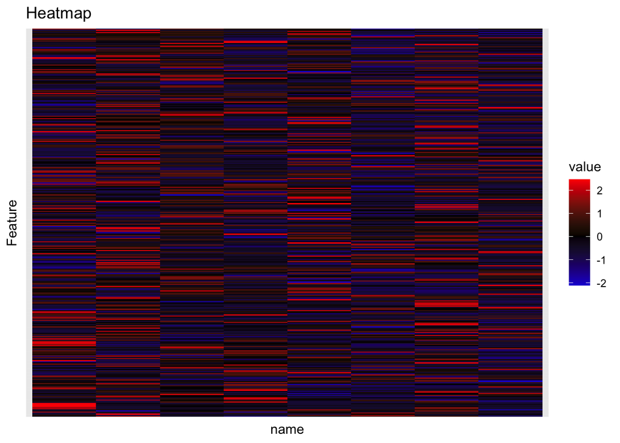

```r
dat=Brown_adipose_2022[,2:9]
dat1=apply(dat,1,function(x) scale(x))
#t(dat1)
dat2=data.frame(Feature=Brown_adipose_2022[,1])
dat3=cbind(dat2, t(dat1))

ggplot(data = pivot_longer(dat3, -Feature), aes(x = name, y = Feature, fill = value)) +
  geom_tile() +
  scale_fill_gradient2(midpoint = 0, low = "blue", mid = "black", high = "red") +
  theme_minimal() +
  labs(title = "Heatmap") +
  theme(axis.text.x = element_text(angle = 48, hjust = 1)) +
  theme(axis.text.y=element_blank(), axis.text.x=element_blank())
```

#MAR data heatmap Extracts columns 10 to 17 from the data frame

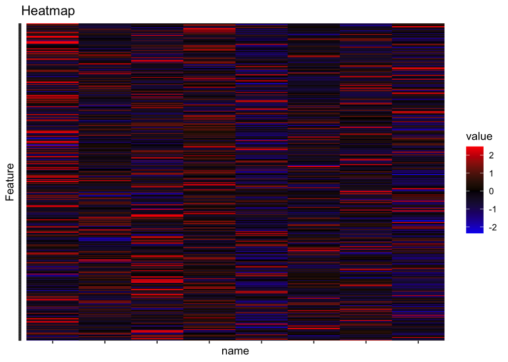

```r
dat=Brown_adipose_2022[,10:17]
dat1=apply(dat,1,function(x) scale(x))
#t(dat1)
dat2=data.frame(Feature=Brown_adipose_2022[,1])
dat3=cbind(dat2, t(dat1))
ggplot(data = pivot_longer(dat3, -Feature), aes(x = name, y = Feature, fill = value)) +
  geom_tile() +
  scale_fill_gradient2(midpoint = 0, low = "blue", mid = "black", high = "red") +
  labs(title = "Heatmap") +
  theme(axis.text.x = element_text(angle = 48, hjust = 1)) +
  theme(axis.text.y=element_blank(), axis.text.x=element_blank())
```

OCT DATA HEATMAP Extracts columns 18 to 26 from the data frame

*DS: You were missing geom_tile() in the ggplot function*

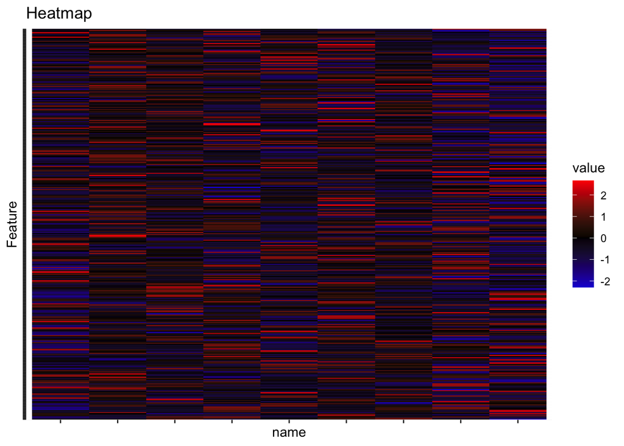

```r
dat=Brown_adipose_2022[,18:26]
dat1=apply(dat,1,function(x) scale(x))
#t(dat1)
dat2=data.frame(Feature=Brown_adipose_2022[,1])
dat3=cbind(dat2, t(dat1))
ggplot(data = pivot_longer(dat3, -Feature), aes(x = name, y = Feature, fill = value)) +
  geom_tile() + #you were missing this line
  scale_fill_gradient2(midpoint = 0, low = "blue", mid = "black", high = "red") +
  labs(title = "Heatmap") +
  theme(axis.text.x = element_text(angle = 48, hjust = 1)) +
  theme(axis.text.y=element_blank(), axis.text.x=element_blank())
```

SEP DATA HEATMAP Extracts columns 27 to 35 from the dataframe

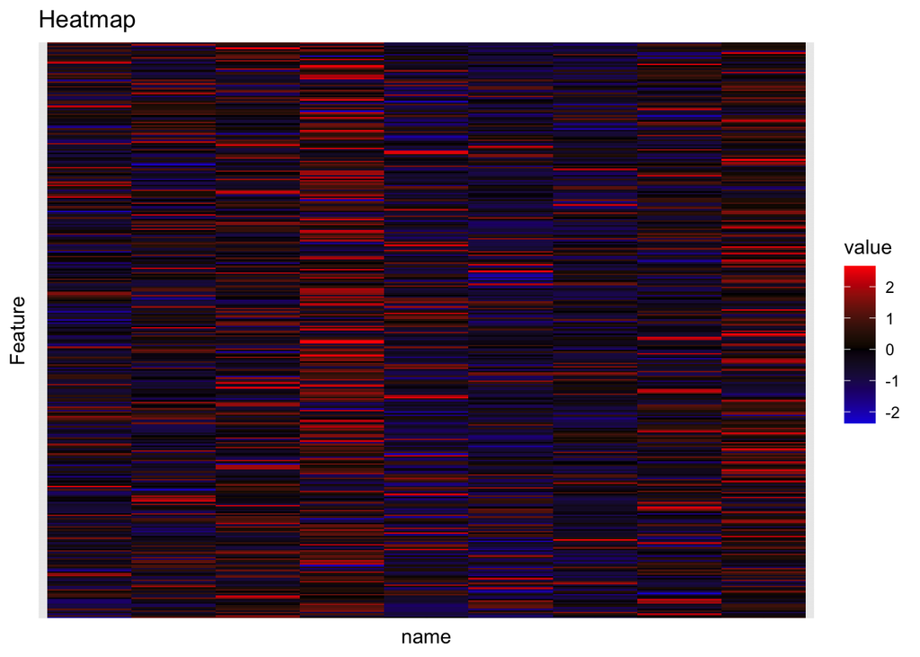

```r
dat=Brown_adipose_2022[,27:35]
dat1=apply(dat,1,function(x) scale(x))
#t(dat1)
dat2=data.frame(Feature=Brown_adipose_2022[,1])
dat3=cbind(dat2, t(dat1))
ggplot(data = pivot_longer(dat3, -Feature), aes(x = name, y = Feature, fill = value)) +
  geom_tile() +
  scale_fill_gradient2(midpoint = 0, low = "blue", mid = "black", high = "red") +
  theme_minimal() +
  labs(title = "Heatmap") +
  theme(axis.text.x = element_text(angle = 48, hjust = 1)) +
  theme(axis.text.y=element_blank(), axis.text.x=element_blank())
```

TOR DATA HEATMAP Extracts columns 36 to 49.

```r
dat=Brown_adipose_2022[,36:49]
dat1=apply(dat,1,function(x) scale(x))
#t(dat1)
dat2=data.frame(Feature=Brown_adipose_2022[,1])
dat3=cbind(dat2, t(dat1))
library(ggplot2)
ggplot(data = pivot_longer(dat3, -Feature), aes(x = name, y = Feature, fill = value)) +
  geom_tile() +
  scale_fill_gradient2(midpoint = 0, low = "blue", mid = "black", high = "red") +
  theme_minimal() +
  labs(title = "Heatmap") +
  theme(axis.text.x = element_text(angle = 48, hjust = 1)) +
  theme(axis.text.y=element_blank(), axis.text.x=element_blank())
```

[output not shown]

Function to determine top metabolites for each variable

```r
get_top_metabolites <- function(data, variable_columns, num_top_metabolites = 10) {
  dat = data[, variable_columns]
  dat1 = apply(dat, 1, function(x) scale(x))
  top_metabolites_indices = apply(dat1, 1, function(x) order(x, decreasing = TRUE)[1:num_top_metabolites])
  top_metabolites = rownames(dat)[top_metabolites_indices]
  return(top_metabolites)
}

# Determine top metabolites for the entire dataset
top_metabolites_all = get_top_metabolites(Brown_adipose_2022, 2:49)
```

```r
# Determine top metabolites for each variable
top_metabolites_IBA = get_top_metabolites(Brown_adipose_2022, 2:9)
top_metabolites_MAR = get_top_metabolites(Brown_adipose_2022, 10:17)
top_metabolites_OCT = get_top_metabolites(Brown_adipose_2022, 18:26)
top_metabolites_SEP = get_top_metabolites(Brown_adipose_2022, 27:35)
top_metabolites_TOR = get_top_metabolites(Brown_adipose_2022, 36:49)

# Print the top metabolites
print(top_metabolites_all)
```

```
##   [1] "193" "11"  "70"  "255" "39"  "12"  "68"  "34"  "10"  "53"  "167" "3"
##  [13] "166" "152" "34"  "141" "139" "232" "110" "56"  "127" "310" "193" "287"
##  [25] "171" "209" "276" "50"  "123" "222" "26"  "342" "127" "35"  "193" "117"
##  [37] "17"  "52"  "114" "182" "268" "115" "254" "44"  "147" "202" "204" "108"
##  [49] "195" "121" "228" "303" "139" "43"  "1"   "48"  "140" "100" "134" "299"
##  [61] "104" "231" "80"  "246" "54"  "192" "87"  "228" "311" "340" "201" "122"
##  [73] "287" "75"  "48"  "290" "175" "222" "100" "111" "332" "135" "354" "222"
##  [85] "326" "241" "209" "331" "128" "344" "355" "309" "290" "47"  "49"  "177"
##  [97] "197" "100" "63"  "159" "147" "183" "60"  "39"  "169" "68"  "356" "69"
## [109] "272" "81"  "292" "325" "169" "347" "345" "177" "25"  "338" "216" "94"
## [121] "334" "156" "244" "177" "267" "85"  "35"  "196" "243" "157" "195" "14"
## [133] "47"  "66"  "159" "52"  "17"  "24"  "1"   "337" "197" "290" "294" "146"
## [145] "299" "157" "81"  "1"   "200" "48"  "38"  "156" "247" "351" "334" "81"
## [157] "288" "244" "4"   "321" "91"  "132" "85"  "160" "289" "96"  "159" "343"
## [169] "351" "173" "45"  "188" "221" "194" "172" "300" "265" "285" "322" "249"
```

[output cut: 25 more lines]

```r
print(top_metabolites_IBA)
```

```
##  [1] "328" "11"  "12"  "70"  "10"  "13"  "149" "71"  "255" "39"  "82"  "3"
## [13] "120" "152" "197" "261" "250" "167" "353" "313" "341" "21"  "66"  "310"
## [25] "338" "94"  "274" "301" "179" "116" "342" "26"  "188" "18"  "17"  "277"
## [37] "52"  "96"  "343" "309" "147" "195" "159" "268" "177" "207" "204" "108"
## [49] "115" "254" "303" "228" "249" "347" "158" "62"  "113" "4"   "155" "43"
## [61] "104" "282" "192" "300" "172" "194" "125" "54"  "340" "86"  "290" "201"
## [73] "138" "101" "81"  "122" "285" "151" "235" "111"
```

```r
print(top_metabolites_MAR)
```

```
##  [1] "340" "332" "198" "222" "128" "241" "331" "179" "135" "333" "92"  "322"
## [13] "175" "138" "309" "355" "120" "281" "282" "90"  "147" "140" "60"  "39"
## [25] "117" "313" "74"  "139" "56"  "68"  "325" "349" "216" "292" "347" "142"
## [37] "25"  "13"  "168" "345" "213" "243" "267" "283" "308" "223" "122" "19"
## [49] "46"  "277" "14"  "195" "30"  "52"  "102" "17"  "227" "165" "104" "320"
## [61] "23"  "188" "294" "146" "106" "64"  "249" "103" "230" "197" "288" "247"
## [73] "134" "303" "276" "145" "351" "109" "163" "29"
```

```r
print(top_metabolites_OCT)
```

```
##  [1] "132" "347" "91"  "85"  "20"  "351" "264" "66"  "126" "106" "45"  "188"
## [13] "336" "221" "212" "29"  "43"  "285" "349" "265" "19"  "223" "122" "247"
## [25] "313" "111" "87"  "118" "114" "99"  "268" "341" "243" "267" "121" "202"
## [37] "67"  "56"  "333" "350" "81"  "228" "262" "46"  "26"  "65"  "158" "77"
## [49] "326" "154" "340" "195" "290" "301" "272" "355" "97"  "295" "204" "149"
## [61] "171" "74"  "236" "288" "176" "23"  "256" "242" "281" "103" "98"  "224"
## [73] "220" "127" "150" "58"  "208" "278" "52"  "17"  "61"  "227" "101" "115"
## [85] "39"  "337" "112" "110" "8"   "25"
```

```r
print(top_metabolites_SEP)
```

```
##  [1] "82"  "244" "315" "342" "266" "277" "27"  "355" "268" "303" "75"  "175"
## [13] "260" "215" "78"  "304" "76"  "323" "20"  "250" "351" "302" "142" "262"
## [25] "14"  "72"  "145" "61"  "212" "98"  "163" "165" "340" "322" "282" "143"
## [37] "162" "257" "214" "301" "291" "136" "295" "229" "79"  "40"  "184" "101"
## [49] "47"  "137" "213" "217" "308" "26"  "19"  "208" "81"  "43"  "225" "146"
## [61] "53"  "246" "276" "85"  "22"  "151" "155" "4"   "235" "103" "341" "71"
## [73] "12"  "313" "167" "272" "140" "51"  "164" "3"   "290" "169" "115" "228"
## [85] "93"  "186" "105" "38"  "298" "348"
```

```r
print(top_metabolites_TOR)
```

```
##   [1] "342" "341" "288" "82"  "243" "144" "279" "33"  "188" "273" "61"  "160"
##  [13] "148" "161" "51"  "143" "56"  "315" "6"   "256" "301" "259" "212" "351"
##  [25] "198" "195" "346" "41"  "25"  "244" "349" "45"  "208" "276" "120" "217"
##  [37] "176" "226" "305" "154" "147" "159" "158" "221" "290" "307" "18"  "40"
##  [49] "206" "23"  "58"  "81"  "272" "91"  "100" "225" "18"  "48"  "95"  "122"
##  [61] "72"  "328" "98"  "66"  "216" "17"  "156" "107" "184" "15"  "71"  "11"
##  [73] "12"  "313" "101" "8"   "34"  "354" "70"  "9"   "207" "162" "257" "187"
##  [85] "330" "310" "204" "152" "166" "213" "96"  "343" "43"  "150" "112" "337"
##  [97] "309" "211" "90"  "244" "125" "115" "344" "52"  "209" "39"  "60"  "9"
## [109] "8"   "265" "157" "299" "249" "145" "171" "114" "355" "111" "169" "196"
## [121] "282" "177" "190" "300" "263" "55"  "26"  "131" "340" "194" "138" "179"
## [133] "94"  "338" "14"  "21"  "142" "248" "280" "50"
```

## Tip: instead of overwriting the data each time when you segment the data, just save them as separate objects. Also, make the data wrangling part into a function. This will clean up the code a lot.

Separate the data into segments

```r
dat.IBA=dat=Brown_adipose_2022[,2:9]
dat.MAR=dat=Brown_adipose_2022[,10:17]
dat.OCT=dat=Brown_adipose_2022[,18:26]
dat.SEP=dat=Brown_adipose_2022[,27:35]
dat.TOR=dat=Brown_adipose_2022[,36:49]
```

Make a function to reorganize the data

```r
dat_for_heatmap=function(x) {
  dat.scale=apply(dat,1,function(x) scale(x))
  features=data.frame(Feature=Brown_adipose_2022[,1])
  dat3=cbind(features, t(dat.scale))
  dat_pivot=pivot_longer(dat3, -Feature)
  dat_pivot
}
```

Here’s for IBA

```r
ggplot(data = dat_for_heatmap(dat.IBA), aes(x = name, y = Feature, fill = value)) +
  geom_tile() +
  scale_fill_gradient2(midpoint = 0, low = "blue", mid = "black", high = "red") +
  theme_minimal() +
  labs(title = "Heatmap") +
  theme(axis.text.x = element_text(angle = 48, hjust = 1)) +
  theme(axis.text.y=element_blank(), axis.text.x=element_blank())
```

[output not shown]

… and for MAR

```r
ggplot(data = dat_for_heatmap(dat.MAR), aes(x = name, y = Feature, fill = value)) +
  geom_tile() +
  scale_fill_gradient2(midpoint = 0, low = "blue", mid = "black", high = "red") +
  theme_minimal() +
  labs(title = "Heatmap") +
  theme(axis.text.x = element_text(angle = 48, hjust = 1)) +
  theme(axis.text.y=element_blank(), axis.text.x=element_blank())
```

[output not shown]